*Transport Analytics Training Series - Last Revision: October 2022*

# Travelling Salesman Problem - Comparison of solutions

**It's Christmas Eve! And Father Christmas is running out of time!** **And he has so many ore homes to visit!**

**What's the best way to find the shortest tour visiting each home only once?**

[figure not shown]

This notebook compares the solutions for travelling salesperson problem derived by using the following algorithms:

1. Nearest neighbour algorithm using $|N|$ number of steps
2. Nearest neighbour algorithm using $|N|^{2}$
3. Nearest neighbour algorithm with 2-opt heuristic
4. Miller, Tucker and Zemlin (MTZ) method
5. Genetic algorithm

The comparison is shown here.

```python
import numpy as np
import matplotlib
import matplotlib.pyplot as plt
from matplotlib import collections
import matplotlib.cm as cm
import seaborn as sns
from sklearn.datasets import make_blobs
from scipy.spatial import distance
import pandas as pd
from pulp import *
from deap import base, creator, tools
import copy
from time import time

%matplotlib inline
```

### Map of 15 homes

We will first create a map of the 15 homes that all the five alogirthms can use as an input.  
(The colors don't mean anything -- the multi-color plot is to make it more festive! )

```python
num_homes = 15

sns.set_style("darkgrid", {"axes.facecolor": "honeydew"})

plot_size   = 16
plot_width  = 20
plot_height = 10

params = {'legend.fontsize': 'large',
          'figure.figsize': (plot_width,plot_height),
          'axes.labelsize': plot_size,
          'axes.titlesize': plot_size,
          'xtick.labelsize': plot_size*0.75,
          'ytick.labelsize': plot_size*0.75,
          'axes.titlepad': 25}
plt.rcParams.update(params)
```

```python
def create_map(homes_coord, homes_coord_dict):

    colors = cm.rainbow(np.linspace(0, 1, len(homes_coord[:, 0])))
    plt.scatter(homes_coord[:, 0],
                homes_coord[:, 1],
                s=plot_size*3,
                color = colors)

    for i in range(num_homes):
        plt.annotate(i, (homes_coord[i, 0]+1, homes_coord[i, 1]+0.5), size=14)
```

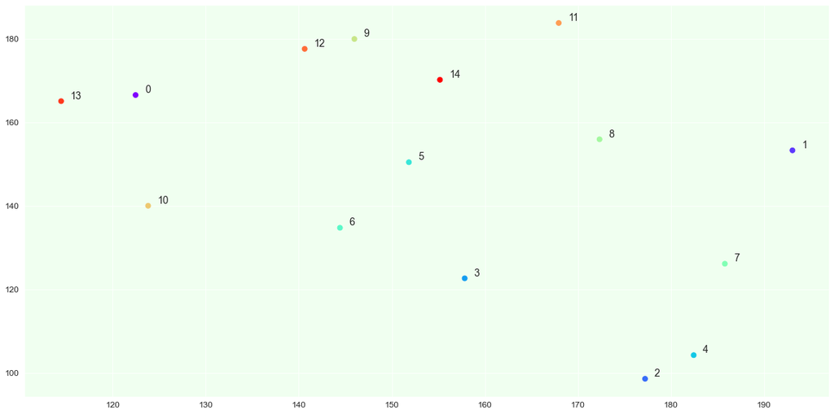

```python
homes_ids = [f'Node {i}' for i in range(num_homes)]
center_box = (100, 200)

homes_coord, _ = make_blobs(n_samples=num_homes,
                           centers=4, # this is to make the home more spatially distributed
                           cluster_std=20,
                           center_box=center_box,
                           random_state = 10)

homes_coord_dict = {name: coord for name,coord in zip(homes_ids, homes_coord)}

create_map(homes_coord, homes_coord_dict)
plt.show()
# create the distance matrix of the homes
dist_matrix = distance.cdist(homes_coord, homes_coord, 'euclidean')
dist_matrix = np.where(dist_matrix==0, np.Inf, dist_matrix)
```

```python
# Generic plot solution function
def plot_solution(_N, _path, _homes_coord, _homes_coord_dict):
    create_map(_homes_coord, _homes_coord_dict)
    lines = []
    for p in range(len(_path) - 1):
        i = _path[p]
        j = _path[p+1]
        colour = 'black'
        plt.arrow(_homes_coord_dict[i][0], _homes_coord_dict[i][1],_homes_coord_dict[j][0] - _homes_coord_dict[i][0], _homes_coord_dict[j][1] - _homes_coord_dict[i][1], color=colour)

    plt.show()
```

### Nearest Neighbour algorithm using $|N|$ steps

```python
start_node = homes_ids[0]  # start from a random home - in our case the first home
```

```python
t0 = time()
name_to_index = {i:idx for idx,i in enumerate(homes_ids)}
visited = [False if start_node is not _ else True for _ in homes_ids]
route_NN = [start_node]
curr = start_node
distance_NN = 0
dist_matrix_copy = copy.deepcopy(dist_matrix)

while False in visited:

    row = dist_matrix_copy[name_to_index[curr]]

    for idx in range(len(row)):
        if visited[idx]:
            row[idx] = np.Inf

    closest = np.argmin(row)

    visited[closest] = True
    curr = homes_ids[closest]
    route_NN.append(curr)
    distance_NN = distance_NN + dist_matrix[[int(s) for s in curr.split() if s.isdigit()][0]][[int(s) for s in route_NN[-2].split() if s.isdigit()][0]]

route_NN.append(start_node)
distance_NN = distance_NN + dist_matrix[[int(s) for s in start_node.split() if s.isdigit()][0]][[int(s) for s in route_NN[-2].split() if s.isdigit()][0]]
time_NN = time() - t0
# for full details see notebook n10_3 - Travelling Salesman Problem - Nearest Neighbour Heuristic
```

### Nearest Neighbour algorithm using $|N|^{2}$ steps

This is the same with nearest neighbour algorithm with N steps but repeating the method for all nodes as starting node.

```python
t0 = time()
distance_N2 = {}
route_N2 = {}
for i in range(len(homes_ids)):
    start_node = homes_ids[i]
    name_to_index = {i:idx for idx,i in enumerate(homes_ids)}
    visited = [False if start_node is not _ else True for _ in homes_ids]
    route_N2[i] = [start_node]
    curr = start_node
    distance_N2[i] = 0
    dist_matrix_copy = copy.deepcopy(dist_matrix)

    while False in visited:

        row = dist_matrix_copy[name_to_index[curr]]

        for idx in range(len(row)):
            if visited[idx]:
                row[idx] = np.Inf

        closest = np.argmin(row)

        visited[closest] = True
        curr = homes_ids[closest]
        distance_N2[i] = distance_N2[i] + dist_matrix[[int(s) for s in curr.split() if s.isdigit()][0]][[int(s) for s in route_N2[i][-1].split() if s.isdigit()][0]]
        route_N2[i].append(curr)

    distance_N2[i] = distance_N2[i] + dist_matrix[[int(s) for s in route_N2[i][0].split() if s.isdigit()][0]][[int(s) for s in route_N2[i][-1].split() if s.isdigit()][0]]
    route_N2[i].append(route_N2[i][0])
time_N2 = time() - t0
```

```python
shortest_dist_N2 = 9999999999999999999999
for k,v in distance_N2.items():
    if v < shortest_dist_N2:
        shortest_dist_N2 = v
        shortest_route_N2 = route_N2[k]
```

### Nearest neighbour algorithm with 2-opt heuristic

Take the shortestroute calculated from nearest neighbour with $|N|^{2}$ steps

```python
dist_matrix_copy = copy.deepcopy(dist_matrix)
shortest_route_N2_copy = copy.deepcopy(shortest_route_N2)
shortest_route_N2_copy.pop()
```

```
'Node 13'
```

```python
def route_eval(_dist_matrix_copy, _route):
    dist = 0
    for p in range(len(_route) - 1):
        _i = _route[p]
        _j = _route[p+1]
        dist += _dist_matrix_copy[[int(s) for s in _i.split() if s.isdigit()][0]][[int(s) for s in _j.split() if s.isdigit()][0]]

    dist += dist_matrix_copy[[int(s) for s in _route[-1].split() if s.isdigit()][0]][[int(s) for s in _route[0].split() if s.isdigit()][0]]
    return dist
```

```python
def two_opt(_dist_matrix_copy, _route):
    stay_in_loop = True
    best_route = _route
    route_length = len(best_route)
    best_fit = route_eval(_dist_matrix_copy, best_route)

    while stay_in_loop:
        stay_in_loop = False
        for i in range(route_length):
            for k in range(i, route_length):
                new_route = best_route[0:i] + list(reversed(best_route[i:k])) + best_route[k:]
                new_route_cost = route_eval(_dist_matrix_copy, new_route)
                if new_route_cost < best_fit:
                    best_fit = new_route_cost
                    best_route = new_route
                    stay_in_loop = True
                    break
            if stay_in_loop:
                break

    best_route.append(best_route[0])
    return best_route, best_fit
```

```python
t0 = time()

two_opt_route, two_opt_dist = two_opt(dist_matrix_copy, shortest_route_N2_copy)
two_opt_time = time() - t0
```

### Miller, Tucker and Zemlin (MTZ) method

```python
dist_matrix_copy = copy.deepcopy(dist_matrix)
```

```python
prob = LpProblem('prob', LpMinimize)

N = [('Node '+str(i)) for i in range(num_homes)]  # the route will start from Node 1
c = {n_f:{n_t: round(dist_matrix_copy[i][j],2) for j,n_t in enumerate(N)} for i,n_f in enumerate(N)}
x = LpVariable.dicts('x',(N,N), 0,1,LpBinary)

prob += lpSum([lpSum([x[i][j]*c[i][j] for j in N if i!=j]) for i in N])

for i in N:
    prob += lpSum([x[i][j] for j in N  if i!=j]) == 1

for j in N:
    prob += lpSum([x[i][j] for i in N  if i!=j]) == 1

# we need to keep track of the order in the tour to eliminate the possibility of subtours
u = LpVariable.dicts('u', N, 0, num_homes-1, LpInteger)

U=num_homes

for i in N:
    for j in N:
        if i != j and (i != 'Node 0' and j!= 'Node 0'):
            prob += u[i] - u[j] <= U*(1-x[i][j]) - 1
```

```python
t0 = time()

%time status = prob.solve()
print(f'\nSTATUS\n{LpStatus[status]}\n')

time_MTZ = time() - t0
```

```
CPU times: user 6.28 ms, sys: 9.54 ms, total: 15.8 ms
Wall time: 1.29 s

STATUS
Optimal
```

```python
route_MTZ = []
distance_MTZ = 0

N_unvisited = N.copy()
current = 'Node 0'
route_MTZ.append(N_unvisited.pop(N_unvisited.index(current)))

while len(N_unvisited) > 0:
    for k in N_unvisited:
        if x[current][k].varValue ==1:
            route_MTZ.append(N_unvisited.pop(N_unvisited.index(k)))
            distance_MTZ = distance_MTZ + dist_matrix_copy[[int(s) for s in route_MTZ[-1].split() if s.isdigit()][0]][[int(s) for s in route_MTZ[-2].split() if s.isdigit()][0]]
            current=k
            break

distance_MTZ = distance_MTZ + dist_matrix_copy[[int(s) for s in route_MTZ[-1].split() if s.isdigit()][0]][[int(s) for s in route_MTZ[0].split() if s.isdigit()][0]]
route_MTZ.append('Node 0')
```

### Genetic algorithm

```python
dist_matrix_copy = copy.deepcopy(dist_matrix)
```

```python
np.random.seed(3)  # we are setting the same random seed to be able to reproduce the answers.
```

```python
def chromo_create(_homes_ids):
    chromo = copy.deepcopy(_homes_ids)
    np.random.shuffle(chromo)
    return chromo
```

```python
def chromo_eval(_dist_matrix_copy, _chromo):
    dist = 0
    for p in range(len(_chromo) - 1):
        _i = _chromo[p]
        _j = _chromo[p+1]
        dist += _dist_matrix_copy[[int(s) for s in _i.split() if s.isdigit()][0]][[int(s) for s in _j.split() if s.isdigit()][0]]

    dist += dist_matrix_copy[[int(s) for s in _chromo[-1].split() if s.isdigit()][0]][[int(s) for s in _chromo[0].split() if s.isdigit()][0]]
    return dist,
```

```python
tb = base.Toolbox()
creator.create('Fitness_Func', base.Fitness, weights=(-1.0,))
creator.create('Individual', list, fitness=creator.Fitness_Func)
```

```python
num_population = 200
num_generations = 2000
prob_crossover = .4
prob_mutation = .6
```

```python
tb.register('indexes', chromo_create, homes_ids)
tb.register('individual', tools.initIterate, creator.Individual, tb.indexes)
tb.register('population', tools.initRepeat, list, tb.individual)
tb.register('evaluate', chromo_eval, dist_matrix_copy)
tb.register('select', tools.selTournament)
tb.register('mate', tools.cxPartialyMatched)
tb.register('mutate', tools.mutShuffleIndexes)
```

```python
population = tb.population(n=num_population)
```

```python
fitness_set = list(tb.map(tb.evaluate, population))
for ind, fit in zip(population, fitness_set):
    ind.fitness.values = fit
```

```python
t0 = time()

best_fit_list = []
best_sol_list = []

best_fit = np.Inf

for gen in range(0, num_generations):

    offspring = tb.select(population, len(population), tournsize=3)
    offspring = list(map(tb.clone, offspring))

    for child1, child2 in zip(offspring[0::2], offspring[1::2]):
        child1_no = [[int(s) for s in i.split() if s.isdigit()][0] for i in child1]
        child2_no = [[int(s) for s in i.split() if s.isdigit()][0] for i in child2]
        if np.random.random() < prob_crossover:
            tb.mate(child1_no, child2_no)
            del child1.fitness.values
            del child2.fitness.values

    for chromo in offspring:
        if np.random.random() < prob_mutation:
            tb.mutate(chromo, indpb=0.01)
            del chromo.fitness.values

    invalid_ind = [ind for ind in offspring if not ind.fitness.valid]
    fitness_set = map(tb.evaluate, invalid_ind)
    for ind, fit in zip(invalid_ind, fitness_set):
        ind.fitness.values = fit

    population[:] = offspring

    curr_best_sol = tools.selBest(population, 1)[0]
    curr_best_fit = curr_best_sol.fitness.values[0]

    if curr_best_fit < best_fit:
        best_sol = curr_best_sol
        best_fit = curr_best_fit

    best_fit_list.append(best_fit)
    best_sol_list.append(best_sol)

time_GA = time() - t0
```

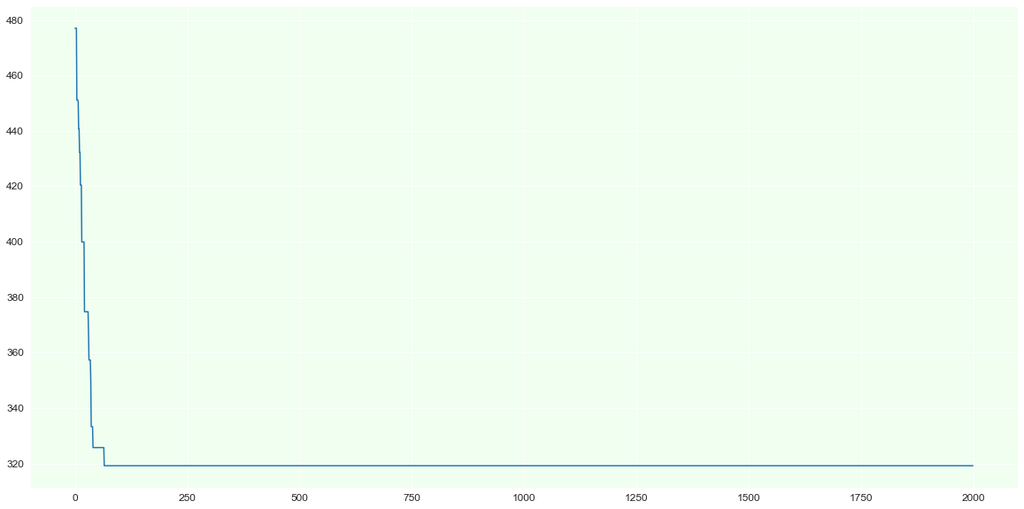

```python
plt.plot(best_fit_list)
plt.show()
```

```python
distance_GA = best_fit_list[-1]
route_GA = []
final_sol = best_sol + best_sol[0:1]
route_GA = final_sol
```

### Individual outputs

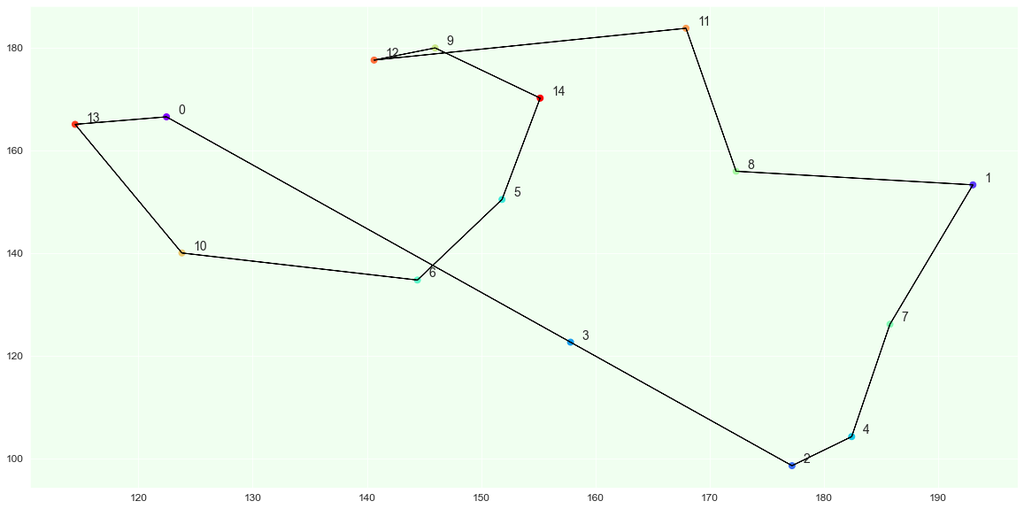

```
335.1060231126455
['Node 0', 'Node 13', 'Node 10', 'Node 6', 'Node 5', 'Node 14', 'Node 9', 'Node 12', 'Node 11', 'Node 8', 'Node 1', 'Node 7', 'Node 4', 'Node 2', 'Node 3', 'Node 0']
0.0008549690246582031
```

```python
# Nearest neighbor
plot_solution(homes_ids, route_NN, homes_coord, homes_coord_dict)
print(distance_NN)
print(route_NN)
print(time_NN)
```

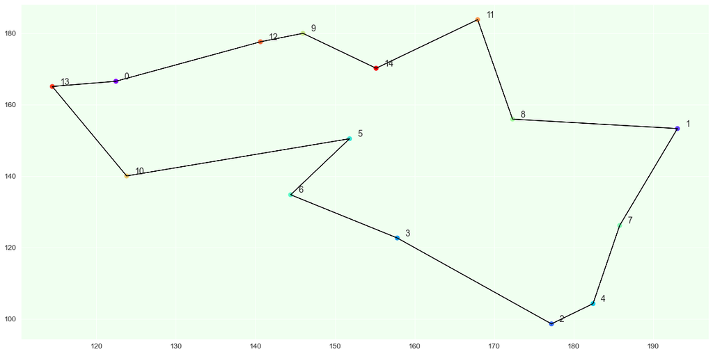

```
['Node 13', 'Node 0', 'Node 12', 'Node 9', 'Node 14', 'Node 11', 'Node 8', 'Node 1', 'Node 7', 'Node 4', 'Node 2', 'Node 3', 'Node 6', 'Node 5', 'Node 10', 'Node 13']
297.3262161693636
0.0034859180450439453
```

```python
# Nearest neighbor with N2
plot_solution(homes_ids, shortest_route_N2, homes_coord, homes_coord_dict)
print(shortest_route_N2)
print(shortest_dist_N2)
print(time_N2)
```

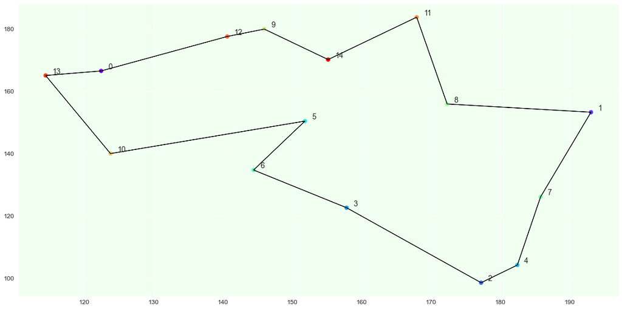

```
['Node 5', 'Node 6', 'Node 3', 'Node 2', 'Node 4', 'Node 7', 'Node 1', 'Node 8', 'Node 11', 'Node 14', 'Node 9', 'Node 12', 'Node 0', 'Node 13', 'Node 10', 'Node 5']
297.32621616936353
0.0034639835357666016
```

```python
# Nearest neighbor with 2-opt
plot_solution(homes_ids, two_opt_route, homes_coord, homes_coord_dict)
print(two_opt_route)
print(two_opt_dist)
print(two_opt_time)
```

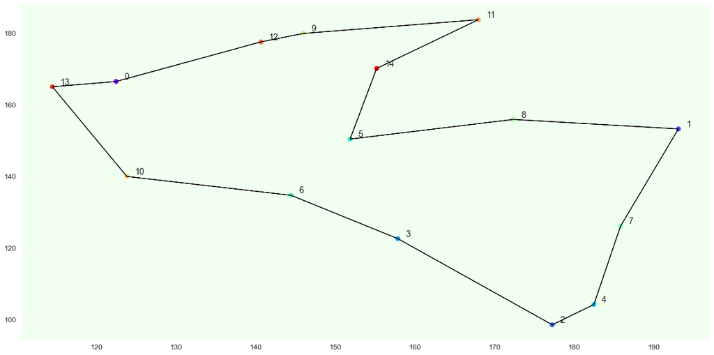

```
['Node 0', 'Node 13', 'Node 10', 'Node 6', 'Node 3', 'Node 2', 'Node 4', 'Node 7', 'Node 1', 'Node 8', 'Node 5', 'Node 14', 'Node 11', 'Node 9', 'Node 12', 'Node 0']
293.26003349704445
1.2862069606781006
```

```python
# MTZ
plot_solution(homes_ids, route_MTZ, homes_coord, homes_coord_dict)
print(route_MTZ)
print(distance_MTZ)
print(time_MTZ)
```

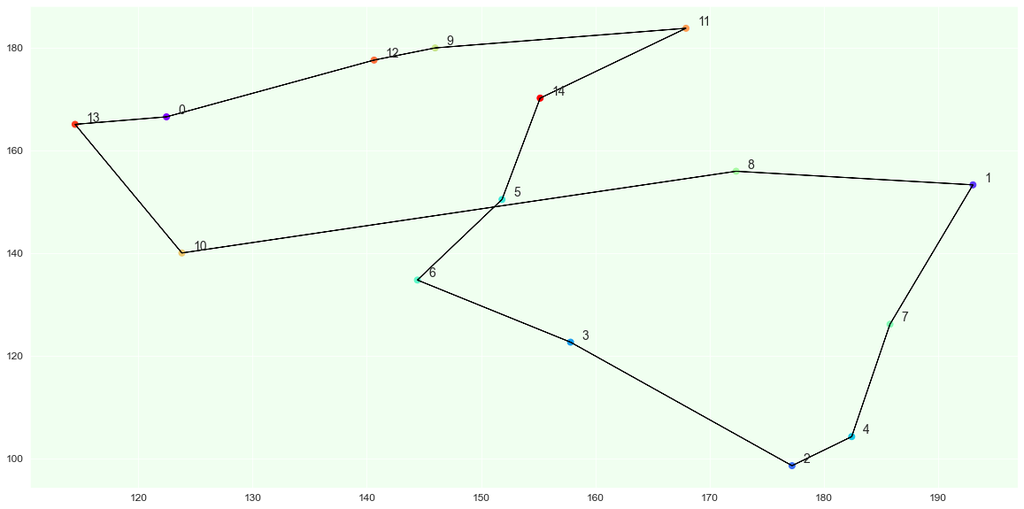

```
['Node 6', 'Node 3', 'Node 2', 'Node 4', 'Node 7', 'Node 1', 'Node 8', 'Node 10', 'Node 13', 'Node 0', 'Node 12', 'Node 9', 'Node 11', 'Node 14', 'Node 5', 'Node 6']
319.18311918491185
19.713893175125122
```

```python
#GA
plot_solution(homes_ids, route_GA, homes_coord, homes_coord_dict)
print(route_GA)
print(distance_GA)
print(time_GA)
```

### Comparison of solutions

```python
def subplot_solution(_N, _path, _homes_coord, _homes_coord_dict):
    create_map(_homes_coord, _homes_coord_dict)
    lines = []
    for p in range(len(_path) - 1):
        i = _path[p]
        j = _path[p+1]
        colour = 'black'
        plt.arrow(_homes_coord_dict[i][0], _homes_coord_dict[i][1],_homes_coord_dict[j][0] - _homes_coord_dict[i][0], _homes_coord_dict[j][1] - _homes_coord_dict[i][1], color=colour)
```

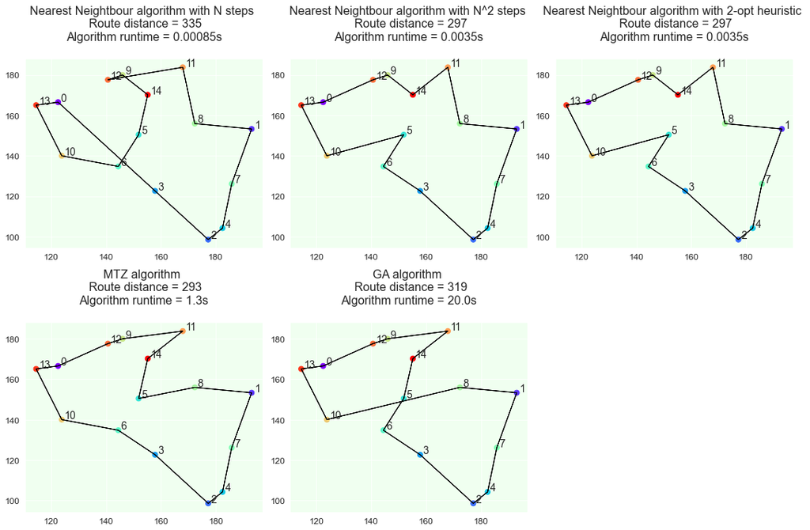

```python
fig = plt.figure(figsize = (15, 10))

#plots
ax1 = plt.subplot(2,3,1, frameon=True)
t1 = 'Route distance = ' + str(int(distance_NN)) + '\nAlgorithm runtime = ' + '%ss' % float('%.2g' % time_NN)
ax1.set_title('Nearest Neightbour algorithm with N steps \n ' + t1)
subplot_solution(homes_ids, route_NN, homes_coord, homes_coord_dict)


ax2 = plt.subplot(2,3,2, frameon=True)
t2 = 'Route distance = ' + str(int(shortest_dist_N2)) + '\nAlgorithm runtime = ' + '%ss' % float('%.2g' % time_N2)
ax2.set_title('Nearest Neightbour algorithm with N^2 steps \n ' + t2)
subplot_solution(homes_ids, shortest_route_N2, homes_coord, homes_coord_dict)

ax3 = plt.subplot(2,3,3)
t3 = 'Route distance = ' + str(int(two_opt_dist)) + '\nAlgorithm runtime = ' + '%ss' % float('%.2g' % two_opt_time)
ax3.set_title('Nearest Neightbour algorithm with 2-opt heuristic \n ' + t3)
subplot_solution(homes_ids, two_opt_route, homes_coord, homes_coord_dict)

ax4 = plt.subplot(2,3,4)
t4 = 'Route distance = ' + str(int(distance_MTZ)) + '\nAlgorithm runtime = ' + '%ss' % float('%.2g' % time_MTZ)
ax4.set_title('MTZ algorithm \n ' + t4)
subplot_solution(homes_ids, route_MTZ, homes_coord, homes_coord_dict)

ax5 = plt.subplot(2,3,5)
t5 = 'Route distance = ' + str(int(distance_GA)) + '\nAlgorithm runtime = ' + '%ss' % float('%.2g' % time_GA)
ax5.set_title('GA algorithm \n ' + t5)
subplot_solution(homes_ids, route_GA, homes_coord, homes_coord_dict)

fig.tight_layout()
```

```python
data = [[distance_NN, shortest_dist_N2, two_opt_dist, distance_MTZ, distance_GA], [time_NN, time_N2, two_opt_time, time_MTZ, time_GA]]
for i in range(num_homes+1):
    data.append([route_NN[i],shortest_route_N2[i],two_opt_route[i],route_MTZ[i],route_GA[i]])
df = pd.DataFrame(data, columns=["NN", "NN^2", "NN+2opt", "MTZ", "GA"])
df.rename(index={0: "total distance"})
df.rename(index={1: "algorithm runtime"})
```

|  | NN | NN^2 | NN+2opt | MTZ | GA |
| --- | --- | --- | --- | --- | --- |
| 0 | 335.106 | 297.326 | 297.326 | 293.26 | 319.183 |
| algorithm runtime | 0.000854969 | 0.00348592 | 0.00346398 | 1.28621 | 19.7139 |
| 2 | Node 0 | Node 13 | Node 5 | Node 0 | Node 6 |
| 3 | Node 13 | Node 0 | Node 6 | Node 13 | Node 3 |
| 4 | Node 10 | Node 12 | Node 3 | Node 10 | Node 2 |
| 5 | Node 6 | Node 9 | Node 2 | Node 6 | Node 4 |
| 6 | Node 5 | Node 14 | Node 4 | Node 3 | Node 7 |
| 7 | Node 14 | Node 11 | Node 7 | Node 2 | Node 1 |
| 8 | Node 9 | Node 8 | Node 1 | Node 4 | Node 8 |
| 9 | Node 12 | Node 1 | Node 8 | Node 7 | Node 10 |
| 10 | Node 11 | Node 7 | Node 11 | Node 1 | Node 13 |
| 11 | Node 8 | Node 4 | Node 14 | Node 8 | Node 0 |
| 12 | Node 1 | Node 2 | Node 9 | Node 5 | Node 12 |
| 13 | Node 7 | Node 3 | Node 12 | Node 14 | Node 9 |
| 14 | Node 4 | Node 6 | Node 0 | Node 11 | Node 11 |
| 15 | Node 2 | Node 5 | Node 13 | Node 9 | Node 14 |
| 16 | Node 3 | Node 10 | Node 10 | Node 12 | Node 5 |
| 17 | Node 0 | Node 13 | Node 5 | Node 0 | Node 6 |